# Risk Factor Analysis

## Outcome Variable

**Outcome Variable:** wasted

## Predictor Variables

**Intervention Variable:** mwtkg

**Adjustment Set:**

unadjusted

## Stratifying Variables

The analysis was stratified on these variable(s):

- agecat
- studyid
- country

## Data Summary

| agecat | studyid | country | mwtkg | wasted | n_cell | n |
| --- | --- | --- | --- | --- | --- | --- |
| Birth | ki0047075b-MAL-ED | BANGLADESH | >=58 kg | 0 | 42 | 233 |
| Birth | ki0047075b-MAL-ED | BANGLADESH | >=58 kg | 1 | 4 | 233 |
| Birth | ki0047075b-MAL-ED | BANGLADESH | <52 kg | 0 | 118 | 233 |
| Birth | ki0047075b-MAL-ED | BANGLADESH | <52 kg | 1 | 26 | 233 |
| Birth | ki0047075b-MAL-ED | BANGLADESH | [52-58) kg | 0 | 34 | 233 |
| Birth | ki0047075b-MAL-ED | BANGLADESH | [52-58) kg | 1 | 9 | 233 |
| Birth | ki0047075b-MAL-ED | BRAZIL | >=58 kg | 0 | 113 | 176 |
| Birth | ki0047075b-MAL-ED | BRAZIL | >=58 kg | 1 | 4 | 176 |
| Birth | ki0047075b-MAL-ED | BRAZIL | <52 kg | 0 | 30 | 176 |
| Birth | ki0047075b-MAL-ED | BRAZIL | <52 kg | 1 | 1 | 176 |
| Birth | ki0047075b-MAL-ED | BRAZIL | [52-58) kg | 0 | 27 | 176 |
| Birth | ki0047075b-MAL-ED | BRAZIL | [52-58) kg | 1 | 1 | 176 |
| Birth | ki0047075b-MAL-ED | INDIA | >=58 kg | 0 | 32 | 195 |
| Birth | ki0047075b-MAL-ED | INDIA | >=58 kg | 1 | 4 | 195 |
| Birth | ki0047075b-MAL-ED | INDIA | <52 kg | 0 | 98 | 195 |
| Birth | ki0047075b-MAL-ED | INDIA | <52 kg | 1 | 23 | 195 |
| Birth | ki0047075b-MAL-ED | INDIA | [52-58) kg | 0 | 33 | 195 |
| Birth | ki0047075b-MAL-ED | INDIA | [52-58) kg | 1 | 5 | 195 |
| Birth | ki0047075b-MAL-ED | NEPAL | >=58 kg | 0 | 51 | 167 |
| Birth | ki0047075b-MAL-ED | NEPAL | >=58 kg | 1 | 5 | 167 |
| Birth | ki0047075b-MAL-ED | NEPAL | <52 kg | 0 | 39 | 167 |
| Birth | ki0047075b-MAL-ED | NEPAL | <52 kg | 1 | 9 | 167 |
| Birth | ki0047075b-MAL-ED | NEPAL | [52-58) kg | 0 | 57 | 167 |
| Birth | ki0047075b-MAL-ED | NEPAL | [52-58) kg | 1 | 6 | 167 |
| Birth | ki0047075b-MAL-ED | PERU | >=58 kg | 0 | 94 | 269 |
| Birth | ki0047075b-MAL-ED | PERU | >=58 kg | 1 | 3 | 269 |
| Birth | ki0047075b-MAL-ED | PERU | <52 kg | 0 | 101 | 269 |
| Birth | ki0047075b-MAL-ED | PERU | <52 kg | 1 | 3 | 269 |
| Birth | ki0047075b-MAL-ED | PERU | [52-58) kg | 0 | 68 | 269 |
| Birth | ki0047075b-MAL-ED | PERU | [52-58) kg | 1 | 0 | 269 |

[output cut: 216 more lines]

The following strata were considered:

- agecat: 24 months, studyid: ki0047075b-MAL-ED, country: BANGLADESH
- agecat: 24 months, studyid: ki0047075b-MAL-ED, country: BRAZIL
- agecat: 24 months, studyid: ki0047075b-MAL-ED, country: INDIA
- agecat: 24 months, studyid: ki0047075b-MAL-ED, country: NEPAL
- agecat: 24 months, studyid: ki0047075b-MAL-ED, country: PERU
- agecat: 24 months, studyid: ki0047075b-MAL-ED, country: SOUTH AFRICA
- agecat: 24 months, studyid: ki0047075b-MAL-ED, country: TANZANIA, UNITED REPUBLIC OF
- agecat: 24 months, studyid: ki1017093-NIH-Birth, country: BANGLADESH
- agecat: 24 months, studyid: ki1017093b-PROVIDE, country: BANGLADESH
- agecat: 24 months, studyid: ki1017093c-NIH-Crypto, country: BANGLADESH
- agecat: 24 months, studyid: ki1066203-TanzaniaChild2, country: TANZANIA, UNITED REPUBLIC OF
- agecat: 24 months, studyid: ki1119695-PROBIT, country: BELARUS
- agecat: 24 months, studyid: ki1126311-ZVITAMBO, country: ZIMBABWE
- agecat: 24 months, studyid: ki1148112-LCNI-5, country: MALAWI
- agecat: 6 months, studyid: ki0047075b-MAL-ED, country: BANGLADESH
- agecat: 6 months, studyid: ki0047075b-MAL-ED, country: BRAZIL
- agecat: 6 months, studyid: ki0047075b-MAL-ED, country: INDIA
- agecat: 6 months, studyid: ki0047075b-MAL-ED, country: NEPAL
- agecat: 6 months, studyid: ki0047075b-MAL-ED, country: PERU
- agecat: 6 months, studyid: ki0047075b-MAL-ED, country: SOUTH AFRICA
- agecat: 6 months, studyid: ki0047075b-MAL-ED, country: TANZANIA, UNITED REPUBLIC OF
- agecat: 6 months, studyid: ki1000304b-SAS-CompFeed, country: INDIA
- agecat: 6 months, studyid: ki1017093-NIH-Birth, country: BANGLADESH
- agecat: 6 months, studyid: ki1017093b-PROVIDE, country: BANGLADESH
- agecat: 6 months, studyid: ki1017093c-NIH-Crypto, country: BANGLADESH
- agecat: 6 months, studyid: ki1066203-TanzaniaChild2, country: TANZANIA, UNITED REPUBLIC OF
- agecat: 6 months, studyid: ki1119695-PROBIT, country: BELARUS
- agecat: 6 months, studyid: ki1126311-ZVITAMBO, country: ZIMBABWE
- agecat: 6 months, studyid: ki1148112-LCNI-5, country: MALAWI
- agecat: Birth, studyid: ki0047075b-MAL-ED, country: BANGLADESH
- agecat: Birth, studyid: ki0047075b-MAL-ED, country: BRAZIL
- agecat: Birth, studyid: ki0047075b-MAL-ED, country: INDIA
- agecat: Birth, studyid: ki0047075b-MAL-ED, country: NEPAL
- agecat: Birth, studyid: ki0047075b-MAL-ED, country: PERU
- agecat: Birth, studyid: ki0047075b-MAL-ED, country: SOUTH AFRICA
- agecat: Birth, studyid: ki0047075b-MAL-ED, country: TANZANIA, UNITED REPUBLIC OF
- agecat: Birth, studyid: ki1000304b-SAS-CompFeed, country: INDIA
- agecat: Birth, studyid: ki1017093-NIH-Birth, country: BANGLADESH
- agecat: Birth, studyid: ki1017093c-NIH-Crypto, country: BANGLADESH
- agecat: Birth, studyid: ki1119695-PROBIT, country: BELARUS
- agecat: Birth, studyid: ki1126311-ZVITAMBO, country: ZIMBABWE

### Dropped Strata

Some strata were dropped due to rare outcomes:

- agecat: Birth, studyid: ki0047075b-MAL-ED, country: BANGLADESH
- agecat: Birth, studyid: ki0047075b-MAL-ED, country: BRAZIL
- agecat: Birth, studyid: ki0047075b-MAL-ED, country: INDIA
- agecat: Birth, studyid: ki0047075b-MAL-ED, country: PERU
- agecat: Birth, studyid: ki0047075b-MAL-ED, country: SOUTH AFRICA
- agecat: Birth, studyid: ki0047075b-MAL-ED, country: TANZANIA, UNITED REPUBLIC OF
- agecat: Birth, studyid: ki1000304b-SAS-CompFeed, country: INDIA
- agecat: Birth, studyid: ki1017093-NIH-Birth, country: BANGLADESH
- agecat: Birth, studyid: ki1017093c-NIH-Crypto, country: BANGLADESH
- agecat: 6 months, studyid: ki0047075b-MAL-ED, country: BANGLADESH
- agecat: 6 months, studyid: ki0047075b-MAL-ED, country: BRAZIL
- agecat: 6 months, studyid: ki0047075b-MAL-ED, country: INDIA
- agecat: 6 months, studyid: ki0047075b-MAL-ED, country: NEPAL
- agecat: 6 months, studyid: ki0047075b-MAL-ED, country: PERU
- agecat: 6 months, studyid: ki0047075b-MAL-ED, country: SOUTH AFRICA
- agecat: 6 months, studyid: ki0047075b-MAL-ED, country: TANZANIA, UNITED REPUBLIC OF
- agecat: 6 months, studyid: ki1017093-NIH-Birth, country: BANGLADESH
- agecat: 6 months, studyid: ki1017093b-PROVIDE, country: BANGLADESH
- agecat: 6 months, studyid: ki1017093c-NIH-Crypto, country: BANGLADESH
- agecat: 6 months, studyid: ki1148112-LCNI-5, country: MALAWI
- agecat: 24 months, studyid: ki0047075b-MAL-ED, country: BANGLADESH
- agecat: 24 months, studyid: ki0047075b-MAL-ED, country: BRAZIL
- agecat: 24 months, studyid: ki0047075b-MAL-ED, country: INDIA
- agecat: 24 months, studyid: ki0047075b-MAL-ED, country: NEPAL
- agecat: 24 months, studyid: ki0047075b-MAL-ED, country: PERU
- agecat: 24 months, studyid: ki0047075b-MAL-ED, country: SOUTH AFRICA
- agecat: 24 months, studyid: ki0047075b-MAL-ED, country: TANZANIA, UNITED REPUBLIC OF
- agecat: 24 months, studyid: ki1017093-NIH-Birth, country: BANGLADESH
- agecat: 24 months, studyid: ki1066203-TanzaniaChild2, country: TANZANIA, UNITED REPUBLIC OF
- agecat: 24 months, studyid: ki1119695-PROBIT, country: BELARUS
- agecat: 24 months, studyid: ki1148112-LCNI-5, country: MALAWI

## Methods Detail

We’re interested in the causal parameters $E[Y_a]$ for all values of $a \in \mathcal{A}$. These parameters represent the mean outcome if, possibly contrary to fact, we intervened to set all units to have $A=a$. Under the randomization and positivity assumptions, these are identified by the statistical parameters $\psi_a=E_W[E_{Y|A,W}(Y|A=a,W)]$. In addition, we’re interested in the mean of $Y$, $E[Y]$ under no intervention (the observed mean). We will estimate these parameters by using SuperLearner to fit the relevant likelihood factors – $E_{Y|A,W}(Y|A=a,W)$ and $p(A=a|W)$, and then updating our likelihood fit using a joint TMLE.

For unadjusted analyses ($W=\{\}$), initial likelihoods were estimated using Lrnr_glm to estimate the simple $E(Y|A)$ and Lrnr_mean to estimate $p(A)$. For adjusted analyses, a small library containing Lrnr_glmnet, Lrnr_xgboost, and Lrnr_mean was used.

Having estimated these parameters, we will then use the delta method to estimate relative risks and attributable risks relative to a prespecified baseline level of $A$.

# Results Detail

## Results Plots

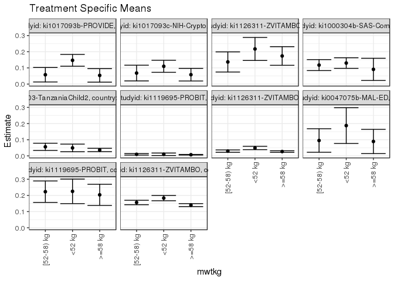

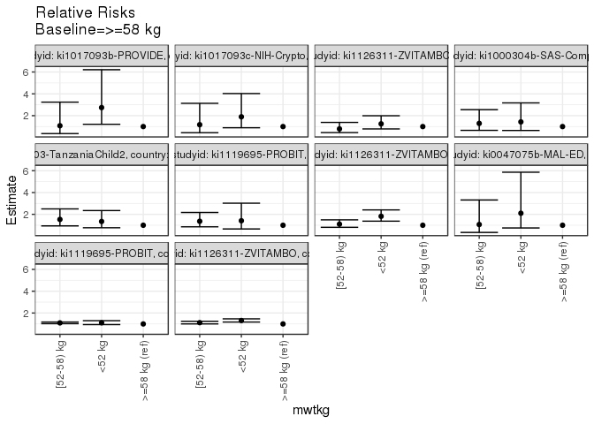

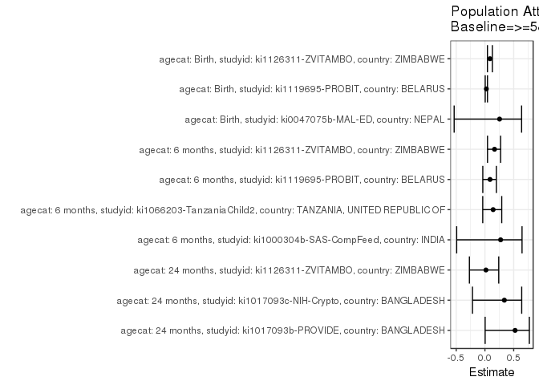

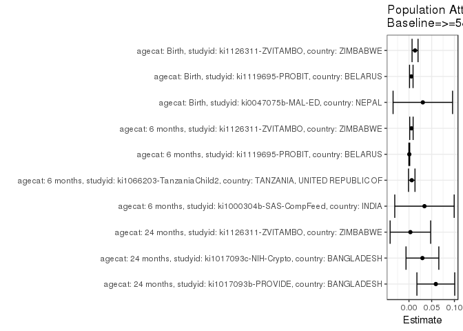

## Results Table

### Parameter: TSM

| agecat | studyid | country | intervention_level | baseline_level | estimate | ci_lower | ci_upper |
| --- | --- | --- | --- | --- | --- | --- | --- |
| Birth | ki0047075b-MAL-ED | NEPAL | >=58 kg | NA | 0.0892857 | 0.0143756 | 0.1641958 |
| Birth | ki0047075b-MAL-ED | NEPAL | <52 kg | NA | 0.1875000 | 0.0767499 | 0.2982501 |
| Birth | ki0047075b-MAL-ED | NEPAL | [52-58) kg | NA | 0.0952381 | 0.0225347 | 0.1679415 |
| Birth | ki1119695-PROBIT | BELARUS | >=58 kg | NA | 0.2035571 | 0.1380576 | 0.2690566 |
| Birth | ki1119695-PROBIT | BELARUS | <52 kg | NA | 0.2250890 | 0.1491063 | 0.3010717 |
| Birth | ki1119695-PROBIT | BELARUS | [52-58) kg | NA | 0.2229787 | 0.1566067 | 0.2893507 |
| Birth | ki1126311-ZVITAMBO | ZIMBABWE | >=58 kg | NA | 0.1398717 | 0.1306668 | 0.1490766 |
| Birth | ki1126311-ZVITAMBO | ZIMBABWE | <52 kg | NA | 0.1834734 | 0.1670814 | 0.1998654 |
| Birth | ki1126311-ZVITAMBO | ZIMBABWE | [52-58) kg | NA | 0.1562500 | 0.1425231 | 0.1699769 |
| 6 months | ki1000304b-SAS-CompFeed | INDIA | >=58 kg | NA | 0.0909091 | 0.0223007 | 0.1595175 |
| 6 months | ki1000304b-SAS-CompFeed | INDIA | <52 kg | NA | 0.1299213 | 0.0972077 | 0.1626348 |
| 6 months | ki1000304b-SAS-CompFeed | INDIA | [52-58) kg | NA | 0.1173709 | 0.0835538 | 0.1511880 |
| 6 months | ki1066203-TanzaniaChild2 | TANZANIA, UNITED REPUBLIC OF | >=58 kg | NA | 0.0366534 | 0.0262546 | 0.0470522 |
| 6 months | ki1066203-TanzaniaChild2 | TANZANIA, UNITED REPUBLIC OF | <52 kg | NA | 0.0493827 | 0.0257847 | 0.0729807 |
| 6 months | ki1066203-TanzaniaChild2 | TANZANIA, UNITED REPUBLIC OF | [52-58) kg | NA | 0.0562347 | 0.0339026 | 0.0785668 |
| 6 months | ki1119695-PROBIT | BELARUS | >=58 kg | NA | 0.0071869 | 0.0053050 | 0.0090687 |
| 6 months | ki1119695-PROBIT | BELARUS | <52 kg | NA | 0.0101570 | 0.0025233 | 0.0177907 |
| 6 months | ki1119695-PROBIT | BELARUS | [52-58) kg | NA | 0.0098127 | 0.0051490 | 0.0144764 |
| 6 months | ki1126311-ZVITAMBO | ZIMBABWE | >=58 kg | NA | 0.0269490 | 0.0220255 | 0.0318725 |
| 6 months | ki1126311-ZVITAMBO | ZIMBABWE | <52 kg | NA | 0.0490724 | 0.0387143 | 0.0594305 |
| 6 months | ki1126311-ZVITAMBO | ZIMBABWE | [52-58) kg | NA | 0.0296793 | 0.0224016 | 0.0369569 |
| 24 months | ki1017093b-PROVIDE | BANGLADESH | >=58 kg | NA | 0.0535714 | 0.0118339 | 0.0953089 |
| 24 months | ki1017093b-PROVIDE | BANGLADESH | <52 kg | NA | 0.1468144 | 0.1102737 | 0.1833551 |
| 24 months | ki1017093b-PROVIDE | BANGLADESH | [52-58) kg | NA | 0.0576923 | 0.0128422 | 0.1025424 |
| 24 months | ki1017093c-NIH-Crypto | BANGLADESH | >=58 kg | NA | 0.0579710 | 0.0189437 | 0.0969984 |
| 24 months | ki1017093c-NIH-Crypto | BANGLADESH | <52 kg | NA | 0.1098901 | 0.0727545 | 0.1470257 |
| 24 months | ki1017093c-NIH-Crypto | BANGLADESH | [52-58) kg | NA | 0.0679612 | 0.0193093 | 0.1166131 |
| 24 months | ki1126311-ZVITAMBO | ZIMBABWE | >=58 kg | NA | 0.1736527 | 0.1161301 | 0.2311753 |
| 24 months | ki1126311-ZVITAMBO | ZIMBABWE | <52 kg | NA | 0.2170543 | 0.1458297 | 0.2882788 |
| 24 months | ki1126311-ZVITAMBO | ZIMBABWE | [52-58) kg | NA | 0.1367521 | 0.0744194 | 0.1990849 |

### Parameter: E(Y)

| agecat | studyid | country | intervention_level | baseline_level | estimate | ci_lower | ci_upper |
| --- | --- | --- | --- | --- | --- | --- | --- |
| Birth | ki0047075b-MAL-ED | NEPAL | NA | NA | 0.1197605 | 0.0703691 | 0.1691519 |
| Birth | ki1119695-PROBIT | BELARUS | NA | NA | 0.2086525 | 0.1430546 | 0.2742504 |
| Birth | ki1126311-ZVITAMBO | ZIMBABWE | NA | NA | 0.1532329 | 0.1462710 | 0.1601947 |
| 6 months | ki1000304b-SAS-CompFeed | INDIA | NA | NA | 0.1250000 | 0.0995459 | 0.1504541 |
| 6 months | ki1066203-TanzaniaChild2 | TANZANIA, UNITED REPUBLIC OF | NA | NA | 0.0427565 | 0.0338612 | 0.0516519 |
| 6 months | ki1119695-PROBIT | BELARUS | NA | NA | 0.0078837 | 0.0058935 | 0.0098738 |
| 6 months | ki1126311-ZVITAMBO | ZIMBABWE | NA | NA | 0.0323396 | 0.0284424 | 0.0362368 |
| 24 months | ki1017093b-PROVIDE | BANGLADESH | NA | NA | 0.1126516 | 0.0868319 | 0.1384714 |
| 24 months | ki1017093c-NIH-Crypto | BANGLADESH | NA | NA | 0.0875486 | 0.0630907 | 0.1120065 |
| 24 months | ki1126311-ZVITAMBO | ZIMBABWE | NA | NA | 0.1767554 | 0.1399213 | 0.2135896 |

### Parameter: RR

| agecat | studyid | country | intervention_level | baseline_level | estimate | ci_lower | ci_upper |
| --- | --- | --- | --- | --- | --- | --- | --- |
| Birth | ki0047075b-MAL-ED | NEPAL | >=58 kg | >=58 kg | 1.0000000 | 1.0000000 | 1.000000 |
| Birth | ki0047075b-MAL-ED | NEPAL | <52 kg | >=58 kg | 2.1000000 | 0.7526752 | 5.859101 |
| Birth | ki0047075b-MAL-ED | NEPAL | [52-58) kg | >=58 kg | 1.0666667 | 0.3430858 | 3.316307 |
| Birth | ki1119695-PROBIT | BELARUS | >=58 kg | >=58 kg | 1.0000000 | 1.0000000 | 1.000000 |
| Birth | ki1119695-PROBIT | BELARUS | <52 kg | >=58 kg | 1.1057779 | 0.9402837 | 1.300400 |
| Birth | ki1119695-PROBIT | BELARUS | [52-58) kg | >=58 kg | 1.0954111 | 1.0232019 | 1.172716 |
| Birth | ki1126311-ZVITAMBO | ZIMBABWE | >=58 kg | >=58 kg | 1.0000000 | 1.0000000 | 1.000000 |
| Birth | ki1126311-ZVITAMBO | ZIMBABWE | <52 kg | >=58 kg | 1.3117265 | 1.1739574 | 1.465664 |
| Birth | ki1126311-ZVITAMBO | ZIMBABWE | [52-58) kg | >=58 kg | 1.1170953 | 1.0009651 | 1.246699 |
| 6 months | ki1000304b-SAS-CompFeed | INDIA | >=58 kg | >=58 kg | 1.0000000 | 1.0000000 | 1.000000 |
| 6 months | ki1000304b-SAS-CompFeed | INDIA | <52 kg | >=58 kg | 1.4291337 | 0.6448248 | 3.167408 |
| 6 months | ki1000304b-SAS-CompFeed | INDIA | [52-58) kg | >=58 kg | 1.2910797 | 0.6535444 | 2.550533 |
| 6 months | ki1066203-TanzaniaChild2 | TANZANIA, UNITED REPUBLIC OF | >=58 kg | >=58 kg | 1.0000000 | 1.0000000 | 1.000000 |
| 6 months | ki1066203-TanzaniaChild2 | TANZANIA, UNITED REPUBLIC OF | <52 kg | >=58 kg | 1.3472893 | 0.7728747 | 2.348619 |
| 6 months | ki1066203-TanzaniaChild2 | TANZANIA, UNITED REPUBLIC OF | [52-58) kg | >=58 kg | 1.5342298 | 0.9417407 | 2.499479 |
| 6 months | ki1119695-PROBIT | BELARUS | >=58 kg | >=58 kg | 1.0000000 | 1.0000000 | 1.000000 |
| 6 months | ki1119695-PROBIT | BELARUS | <52 kg | >=58 kg | 1.4132700 | 0.6610782 | 3.021325 |
| 6 months | ki1119695-PROBIT | BELARUS | [52-58) kg | >=58 kg | 1.3653625 | 0.8580904 | 2.172516 |
| 6 months | ki1126311-ZVITAMBO | ZIMBABWE | >=58 kg | >=58 kg | 1.0000000 | 1.0000000 | 1.000000 |
| 6 months | ki1126311-ZVITAMBO | ZIMBABWE | <52 kg | >=58 kg | 1.8209370 | 1.3773859 | 2.407322 |
| 6 months | ki1126311-ZVITAMBO | ZIMBABWE | [52-58) kg | >=58 kg | 1.1013130 | 0.8111640 | 1.495247 |
| 24 months | ki1017093b-PROVIDE | BANGLADESH | >=58 kg | >=58 kg | 1.0000000 | 1.0000000 | 1.000000 |
| 24 months | ki1017093b-PROVIDE | BANGLADESH | <52 kg | >=58 kg | 2.7405355 | 1.2095689 | 6.209266 |
| 24 months | ki1017093b-PROVIDE | BANGLADESH | [52-58) kg | >=58 kg | 1.0769231 | 0.3582567 | 3.237241 |
| 24 months | ki1017093c-NIH-Crypto | BANGLADESH | >=58 kg | >=58 kg | 1.0000000 | 1.0000000 | 1.000000 |
| 24 months | ki1017093c-NIH-Crypto | BANGLADESH | <52 kg | >=58 kg | 1.8956044 | 0.8924902 | 4.026169 |
| 24 months | ki1017093c-NIH-Crypto | BANGLADESH | [52-58) kg | >=58 kg | 1.1723301 | 0.4388000 | 3.132082 |
| 24 months | ki1126311-ZVITAMBO | ZIMBABWE | >=58 kg | >=58 kg | 1.0000000 | 1.0000000 | 1.000000 |
| 24 months | ki1126311-ZVITAMBO | ZIMBABWE | <52 kg | >=58 kg | 1.2499332 | 0.7841336 | 1.992432 |
| 24 months | ki1126311-ZVITAMBO | ZIMBABWE | [52-58) kg | >=58 kg | 0.7875037 | 0.4482751 | 1.383441 |

### Parameter: PAR

| agecat | studyid | country | intervention_level | baseline_level | estimate | ci_lower | ci_upper |
| --- | --- | --- | --- | --- | --- | --- | --- |
| Birth | ki0047075b-MAL-ED | NEPAL | >=58 kg | NA | 0.0304748 | -0.0350051 | 0.0959546 |
| Birth | ki1119695-PROBIT | BELARUS | >=58 kg | NA | 0.0050954 | 0.0012233 | 0.0089675 |
| Birth | ki1126311-ZVITAMBO | ZIMBABWE | >=58 kg | NA | 0.0133612 | 0.0067795 | 0.0199429 |
| 6 months | ki1000304b-SAS-CompFeed | INDIA | >=58 kg | NA | 0.0340909 | -0.0312943 | 0.0994761 |
| 6 months | ki1066203-TanzaniaChild2 | TANZANIA, UNITED REPUBLIC OF | >=58 kg | NA | 0.0061032 | -0.0010196 | 0.0132259 |
| 6 months | ki1119695-PROBIT | BELARUS | >=58 kg | NA | 0.0006968 | -0.0002776 | 0.0016712 |
| 6 months | ki1126311-ZVITAMBO | ZIMBABWE | >=58 kg | NA | 0.0053906 | 0.0016522 | 0.0091289 |
| 24 months | ki1017093b-PROVIDE | BANGLADESH | >=58 kg | NA | 0.0590802 | 0.0174581 | 0.1007024 |
| 24 months | ki1017093c-NIH-Crypto | BANGLADESH | >=58 kg | NA | 0.0295776 | -0.0065257 | 0.0656810 |
| 24 months | ki1126311-ZVITAMBO | ZIMBABWE | >=58 kg | NA | 0.0031028 | -0.0415031 | 0.0477086 |

### Parameter: PAF

| agecat | studyid | country | intervention_level | baseline_level | estimate | ci_lower | ci_upper |
| --- | --- | --- | --- | --- | --- | --- | --- |
| Birth | ki0047075b-MAL-ED | NEPAL | >=58 kg | NA | 0.2544643 | -0.5355267 | 0.6380242 |
| Birth | ki1119695-PROBIT | BELARUS | >=58 kg | NA | 0.0244205 | 0.0045307 | 0.0439128 |
| Birth | ki1126311-ZVITAMBO | ZIMBABWE | >=58 kg | NA | 0.0871953 | 0.0433449 | 0.1290357 |
| 6 months | ki1000304b-SAS-CompFeed | INDIA | >=58 kg | NA | 0.2727272 | -0.4916470 | 0.6454083 |
| 6 months | ki1066203-TanzaniaChild2 | TANZANIA, UNITED REPUBLIC OF | >=58 kg | NA | 0.1427420 | -0.0381470 | 0.2921125 |
| 6 months | ki1119695-PROBIT | BELARUS | >=58 kg | NA | 0.0883854 | -0.0371253 | 0.1987070 |
| 6 months | ki1126311-ZVITAMBO | ZIMBABWE | >=58 kg | NA | 0.1666867 | 0.0445926 | 0.2731781 |
| 24 months | ki1017093b-PROVIDE | BANGLADESH | >=58 kg | NA | 0.5244505 | 0.0033677 | 0.7730885 |
| 24 months | ki1017093c-NIH-Crypto | BANGLADESH | >=58 kg | NA | 0.3378422 | -0.2166810 | 0.6396320 |
| 24 months | ki1126311-ZVITAMBO | ZIMBABWE | >=58 kg | NA | 0.0175539 | -0.2701596 | 0.2400953 |